```python
from mpl_toolkits.mplot3d import axes3d
import matplotlib.pyplot as plt
import numpy as np
%matplotlib inline
```

**PCA**

Table of Contents

# 1. Principal Component Analysis

**Motivation: Can we describe high-dimensional data in a "simpler" way?**  
$\qquad \qquad \rightarrow$ Dimension reduction without losing too much information  
$\qquad \qquad \rightarrow$ Find a low-dimensional, yet useful representation of the data

- Why dimensionality reduction?
  - insights into the low-dimensinal structures in the data (visualization)
  - Fewer dimensions ⇒ Less chances of overfitting ⇒ Better generalization
  - Speeding up learning algorithms
    - Most algorithms scale badly with increasing data dimensionality
  - Less storage requirements (data compression)
  - Note: Dimensionality Reduction is different from Feature Selection
    - .. although the goals are kind of the same
  - Dimensionality reduction is more like “Feature Extraction”
    - Constructing a small set of new features from the original features
- How?  
  idea: highly correlated data contains redundant features

[figure not shown]

[output not shown]

[output not shown]

[output not shown]

- Data $\rightarrow$ projection onto unit vector $\hat{u}_1$
  - PCA is used when we want projections capturing maximum variance directions
  - Principal Components (PC): directions of maximum variability in the data
  - Roughly speaking, PCA does a change of axes that can represent the data in a succinct manner

[figure not shown]

- HOW?
  1. Maximize variance (most separable)
  2. Minimize the sum-of-squares (minimum squared error)

## Pre-processing

- Given data $$ x^{(i)} = \begin{bmatrix} x^{(i)}_1 \\ \vdots \\x^{(i)}_n \end{bmatrix},\qquad X = \begin{bmatrix} \cdots & (x^{(1)})^T & \cdots\\ \cdots & (x^{(2)})^T & \cdots\\ & \vdots & \\ \cdots & (x^{(m)})^T & \cdots\\ \end{bmatrix}$$
- Shifting (zero mean) and rescaling (unit variance)
  1. Shift to zero mean $$ \begin{align*} \mu &= \frac{1}{m}\sum\limits_{i=1}^{m}x^{(i)} \\ x^{(i)} &\leftarrow x^{(i)} - \mu \quad \text{(zero mean)} \end{align*} $$
  2. [optional] Rescaling (unit variance) $$\begin{align*} \sigma^2_j &= \frac{1}{m-1}\sum\limits_{i=1}{m}\left(x_j^{(i)}\right)^2 \\ x^{(i)}_j &\leftarrow \frac{x^{(i)}_j}{\sigma_j} \\ \end{align*}$$

## 1. Maximize variance

- Find unit vector $u$ such that maximizes variance of projections

  Note: $m \approx m-1$ for big data

$$\begin{align*} \text{variance of projected data} & = \frac{1}{m}\sum\limits_{i=1}^{m}\big(u^Tx^{(i)}\big)^2 = \frac{1}{m}\sum\limits_{i=1}^{m}\big( {x^{(i)}}^Tu\big)^2 \\ & = \frac{1}{m}\sum\limits_{i=1}^{m}\big( {x^{(i)}}^Tu\big)^T\big( {x^{(i)}}^Tu\big) = \frac{1}{m}\sum\limits_{i=1}^{m}u^Tx^{(i)}{x^{(i)}}^Tu \\ & = u^T\left(\frac{1}{m}\sum\limits_{i=1}^{m}x^{(i)}{x^{(i)}}^T \right) u \\ & =u^TSu \qquad (S=\frac{1}{m}X^T X: \text{sample covariance matrix}) \end{align*}$$

- In an optimization form

$$\begin{align*} \text{maximize} \quad & u^TSu \\ \text{subject to} \quad & u^Tu = 1\end{align*}$$

$$\begin{align*} & u^TSu = u^T\lambda u = \lambda u^Tu = \lambda \quad (\text{Eigen analysis} : Su = \lambda u) \\ \\ & \implies \text{pick the largest eigenvalue } \lambda _1 \text{ of covariance matrix } S\\ & \implies u = u_1 \, \text{ is the } \,\lambda_1's \,\text{ corresponding eigenvector}\\ & \implies u_1 \text{ is the first principal component (direction of highest variance in the data)} \end{align*}$$

## 2. Minimize the sum-of-squared error

[output not shown]

$$\begin{align*} \frac {1}{m} \sum\limits_{i=1}^{m} \lVert e^{(i)} \rVert ^2 & = \frac {1}{m} \sum\limits_{i=1}^{m} \lVert x^{(i)} \rVert ^2 - \frac{1}{m}\sum\limits_{i=1}^{m}u^Tx^{(i)}{x^{(i)}}^Tu \\ & = \frac {1}{m} \sum\limits_{i=1}^{m} \lVert x^{(i)} \rVert ^2 - u^T\left(\frac{1}{m}\sum\limits_{i=1}^{m}x^{(i)}{x^{(i)}}^T\right)u \end{align*}$$

- In an optimization form $$\begin{align*} &\text{minimize} \; \underbrace{\frac {1}{m} \sum\limits_{i=1}^{m} \lVert x^{(i)} \rVert ^2}_{\text{constant given $x_i$}} - \underbrace{u^T\left(\frac{1}{m}\sum\limits_{i=1}^{m}x^{(i)}{x^{(i)}}^T\right)u}_{\text{maximize}} \\ \\ \implies &\text{maximize} \; u^T\left(\frac{1}{m}\sum\limits_{i=1}^{m}x^{(i)}{x^{(i)}}^T\right)u = \max \; u^T S u\end{align*}$$

$$ \therefore \; \text{minimize} \; error^2 = \text{maximize} \; variance$$

## Dimension Reduction method ($n \rightarrow k$)

1. Choose top $k$ (orthonormal) eigenvectors, $U = [u_1, u_2, \cdots, u_k]$
2. Project $x_i$ onto span $\{ u_1, u_2, \cdots, u_k\}$

$$z^{(i)} = \begin{bmatrix} u_1^Tx^{(i)}\\ u_2^Tx^{(i)}\\ \vdots \\ u_k^Tx^{(i)}\\ \end{bmatrix} \;\text{ or }\; z = U^{T}x $$

- Pictorial summary of PCA

[figure not shown]

$\qquad \qquad \qquad x^{(i)} \rightarrow$ projection onto unit vector $u \implies u^Tx^{(i)} = $ distance from the origin along $u$

```python
#data generation

m = 1000
mu = np.array([0, 0])
sigma = np.array([[1, 1.5], [1.5, 3]])
r = np.random.multivariate_normal(mu, sigma, m)
x = np.transpose(np.array([r[:, 0]]))
y = np.transpose(np.array([r[:, 1]]))

X = np.concatenate((x, y), axis = 1)
np.shape(r)
```

```
(1000, 2)
```

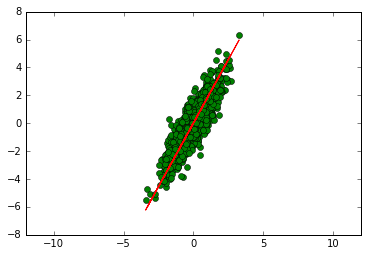

```python
#Assume we do not know mu and SIGMA only X is given
S = np.cov(np.transpose(r))
V, D = np.linalg.eig(S)

V = np.diag(V)
u1 = D[:, 1]/(np.linalg.norm(D[:, 1]))
h = u1[1]/u1[0]

plt.plot(X[:, 0], X[:, 1], 'go')
plt.plot(x, x.dot(h), 'r')
axis('equal')
plt.show()
```

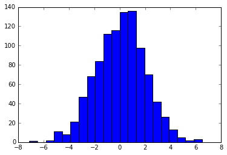

```python
Z = r.dot(u1) # this is new 1dim (reduced or porjected) data vis PCA
plt.hist(Z, 21)
plt.show()
```

# 2. PCA example

- multiple video camera records of spring and mass system

[figure not shown]

- source:
  - https://www.cs.princeton.edu/picasso/mats/PCA-Tutorial-Intuition_jp.pdf

```python
%%html
<iframe
width="560" height="315" src="https://www.youtube.com/embed/Pkit-64g0eU" frameborder="0" allowfullscreen>
</iframe>
```

[video not shown]

```python
%%html
<iframe
width="560" height="315" src="https://www.youtube.com/embed/x4lvjVjUUqg" frameborder="0" allowfullscreen>
</iframe>
```

[video not shown]

```python
%%html
<iframe
width="560" height="315" src="https://www.youtube.com/embed/2t62WkNIqxY" frameborder="0" allowfullscreen>
</iframe>
```

[video not shown]

$$ x^{(i)} = \begin{bmatrix} x \text{ in camera 1} \\ y \text{ in camera 1} \\x \text{ in camera 2}\\y \text{ in camera 2}\\x \text{ in camera 3}\\y \text{ in camera 3} \end{bmatrix},\qquad X = \begin{bmatrix} \vdots & \vdots & & \vdots\\ (x^{(1)}) & (x^{(2)}) & \cdots & (x^{(m)})\\ \vdots & \vdots & & \vdots\\ \end{bmatrix}$$

```python
% read video files
obj1 = VideoReader([pwd,'\image_files\3-cut.mp4']);
obj2 = VideoReader([pwd,'\image_files\4-cut.mp4']);
obj3 = VideoReader([pwd,'\image_files\5-cut.mp4']);

% Unifiy video frames number to the smallest

vidFrames1 = read(obj1);
vidFrames2 = read(obj2);
vidFrames3 = read(obj3);
val = min([size(vidFrames1,4) size(vidFrames2,4) size(vidFrames3,4)]);
```

```python
% tracking the object
% tracking red color
% you do not need to understand how to track the object in this class

% pos_data = [];
% for j = 1:3
%     position = zeros(2,val);
%     for i = 1:val
%         % Read i-th frame in j-th video
%         eval(['data = vidFrames',num2str(j),'(:,:,:,i);'])
%         % (Red layer matrix) - (Gray scale matrix)
%         diff_im = imsubtract(data(:,:,1), rgb2gray(data));
%         % Filter the noise by median filter
%         diff_im = medfilt2(diff_im, [3 3]);
%         % Binary image with threshold 0.18
%         diff_im = im2bw(diff_im,0.18);
%         % Object less than 300 pixels is removed
%         diff_im = bwareaopen(diff_im,300);
%         % Label the objects
%         bw = bwlabel(diff_im, 8);
%         % Measure COM of connected object in binary image
%         stats = regionprops(bw,'Centroid');
%
%         for object = 1:length(stats)
%             bc = stats(object).Centroid;
%         end
%
%         position(:,i) = [bc(1); bc(2)];
%     end
%
%     pos_data = [pos_data; position];
% end

% save camera_recording pos_data

load([pwd,'\image_files\camera_recording.mat']);
```

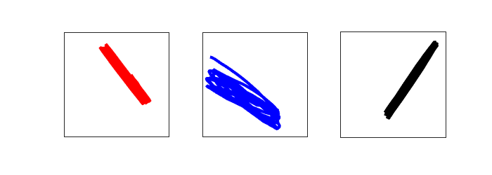

```python
%plot -s 700,250
% trajectory

X = pos_data;

pos = X(1:2, :);
subplot(1,3,1),   plot(pos(1, :),-pos(2, :),'r','linewidth',2)
axis square,    set(gca,'xtick',[]),    set(gca,'ytick',[])

pos = X(3:4, :);
subplot(1,3,2),   plot(pos(1, :),-pos(2, :),'b','linewidth',2)
axis square,    set(gca,'xtick',[]),    set(gca,'ytick',[])

pos = X(5:6, :);
subplot(1,3,3),   plot(pos(1, :),-pos(2, :),'k','linewidth',2)
axis square,    set(gca,'xtick',[]),    set(gca,'ytick',[])
```

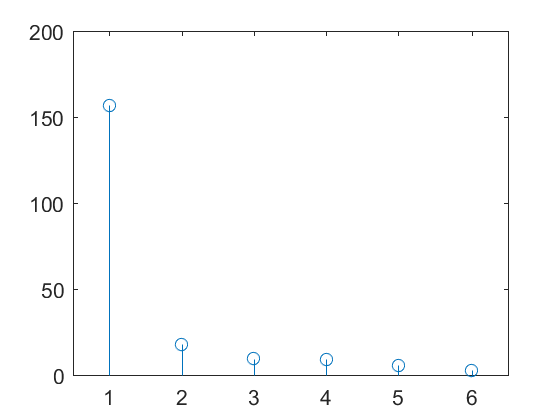

```python
%% PCA
[n,m] = size(X);
Xbar = mean(X,2);           % compute mean for each row
X = X - repmat(Xbar,1,m);   % subtract mean

S = 1/(m-1)*X*X';           % covariance matrix

[U,D] = eig(S);             % eigenvectors and eigenvalues
[d,I] = sort(diag(D),'descend');
U = U(:,I);


stem(sqrt(d))
xlim([0.5 6.5])
```

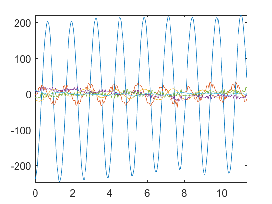

```python
% produce the principal components projection (coordinate changes in U)
Z = U'*X;

xpt = (0:m-1)*1/24;
plot(xpt,Z), axis tight
```

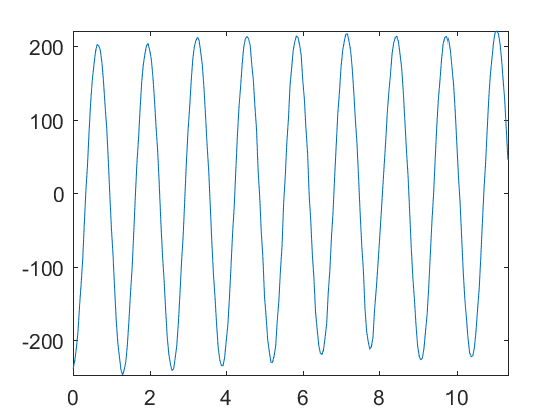

```python
%% projected onto the first principal component
% 6 dim -> 1 dim (dim reduction)

plot(xpt,Z(1,:)), axis tight
```

Reference: John P Cunningham & Byron M Yu, Dimensionality reduction for large-scale neural recordings, Nature Neuroscience 17, 1500–1509 (2014)

[figure not shown]

# 3. PCA Visualization

## 3.1. Eigenvalues

- $\lambda_1, \lambda_2$ indicates variance along the eigenvectors, respectively.
  - The larger eigenvalue is, the more dominante feature (eigenvector) is

[figure not shown]

## 3.2. Eigenvectors

- given basis $\{\hat{x}_1, \hat{x}_2\}$ to transformed basis $\{\hat{u}_1, \hat{u}_2\}$

|  | $$[\hat{u}_1\; \hat{u}_2]=[\hat{x}_1 \; \hat{x}_2]\begin{bmatrix} c_1 & c_3 \\c_2 & c_4\end{bmatrix}$$ |
| --- | --- |

## 3.3. PCA Visualization

- example

[figure not shown]

## 3.4. PCA Interactive Visualization

- example

[figure not shown]

# 4. Probabilistic PCA (Optional)

- Assume the following generative model for each observation $x_i$

$$ x_i = W z_i + \varepsilon_i$$

- Note: We'll assume data to be centered, otherwise $x_i = \mu + W z_i + \varepsilon_i$
- Think of it as low dimensional $z_i \in \mathbb{R}^k$ generating a higher-dimensional $x_i \in \mathbb{R}^n$ via a mapping matrix $W \in \mathbb{R}^{n\times k}$, plus some noise $\varepsilon_i \sim N\left( 0,\sigma^2 I_{n \times n} \right)$
- Probabilistic Graph Model

[figure not shown]

## Interpreting Probabilistic PCA

- We can also write $x_i = W z_i + \varepsilon_i$ as each example $x_i$ being a linear combination of columns $W = [\omega_1,\cdots,\omega_k]$, plus some noise $\varepsilon_i$

$$ \begin{bmatrix} x_1 \\ x_2 \\ \vdots \\\vdots\\x_n \end{bmatrix} = \begin{bmatrix} & & & \\\vert & \vert & & \vert \\\omega_1 & \omega_2 & \cdots & \omega_k \\ \vert & \vert & & \vert \\& & & \end{bmatrix} \begin{bmatrix} z_1\\z_2\\ \vdots\\z_k \end{bmatrix} + \begin{bmatrix} \varepsilon_1\\\varepsilon_2\\\vdots \\ \varepsilon_{n-1} \\\varepsilon_n \end{bmatrix} $$$$x = W z + \varepsilon$$

- (latent variables) distributional assumption

$$z \sim N(0,I_{k}), \qquad \varepsilon \sim N(0,\sigma^2I_{n})$$

- (observed variables) induced distribution on observations

$$x \sim N(0,WW^T+\sigma^2I_n)$$

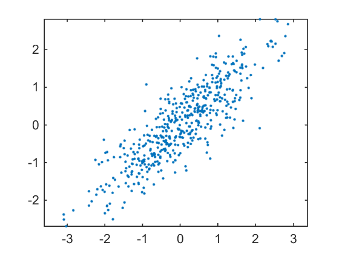

```python
m = 500;
x = randn(m,1);
W = [1;
     1];
mu = [0; 0];
sigma = 0.1*[2 0;0 1];
noise = mvnrnd(mu,sigma,m);

y = x*W' + noise;

plot(y(:,1),y(:,2),'.')
axis equal
```

```python
% compare U(:,1) and W = [1 1]'
pca(y)
```

```
ans =

    0.7294   -0.6841
    0.6841    0.7294
```

```python
%%javascript
$.getScript('https://kmahelona.github.io/ipython_notebook_goodies/ipython_notebook_toc.js')
```